# Philadelphia Property Tax Delinquency: Investor Impact

Joy Payton

11/30/2016

## Load Libraries

```r
library(dplyr)
library(stringr)
library(jsonlite)
```

## Obtain Tax Data

We can get property tax delinquency data from Philadelphia’s Open Data site:

```r
csv <- "https://data.phila.gov/api/views/4v5p-qi2q/rows.csv?accessType=DOWNLOAD&bom=true"
taxData <- read.csv(csv, stringsAsFactors = FALSE)
```

## Clean Data

Remove columns that don’t interest us:

```r
taxDataCleaned <- taxData %>% select(-c(Unit,Lien.Number))
```

Remove rows that won’t help us because they list no owner:

```r
taxDataCleaned <- taxDataCleaned %>% filter(Owner != "")
```

Clean out the $ found in the money fields and convert to numeric

```r
taxDataCleaned$Principal <- as.numeric(gsub('\\$','',taxDataCleaned$Principal))
taxDataCleaned$Interest <- as.numeric(gsub('\\$','',taxDataCleaned$Interest))
taxDataCleaned$Penalty <- as.numeric(gsub('\\$','',taxDataCleaned$Penalty))
taxDataCleaned$Other <- as.numeric(gsub('\\$','',taxDataCleaned$Other))
taxDataCleaned$Total <- as.numeric(gsub('\\$','',taxDataCleaned$Total))
```

Get just 2000-2015 tax amount owed. 2016 represents bills that may not truly be in delinquency yet, and prior to 2000 is too far back for us to be interested.

```r
lastFifteenData <- taxDataCleaned %>% filter(Tax.Period < 2016, Tax.Period >= 2000)
```

## What is the impact of investors?

As a secondary exploration into our data, we’ll want to see what the impact of investors is (we saw some interesting trends of large investors in our [“Worst 100 Tax Delinquents” visualization](http://codepen.io/kjoypayton/full/JbyyJx/)).

Let’s limit our investigation to the last year - 2015. We’ll take only those properties that have overdue tax and do some summarizing. We consider a “deadbeat investor” to be someone with three or more overdue properties.

```r
investors <- lastFifteenData %>%
                    filter(Tax.Period == 2015, Total >0) %>%
                    group_by(Owner) %>%
                    summarise(TotalOwed = sum(Total),
                              NumOverdueProperties = n()) %>%
                    arrange(desc(NumOverdueProperties)) %>%
                    filter(NumOverdueProperties >=3)
```

We have 1449 potential investors… but we know that some are actually governmental agencies. Let’s remove those as we discover them:

```r
investors <- investors %>% filter(Owner != "PHILA HOUSING AUTHORITY")
investors <- investors %>% filter(Owner != "CITY OF PHILADELPHIA")
investors <- investors %>% filter(Owner != "ADMIN OF VET AFFAIRS")
investors <- investors %>% filter(Owner != "OFFICE OF THE DISTRICT AT")
investors <- investors %>% filter(Owner != "ADMIN OF VETS AFFAIRS")
investors <- investors %>% filter(Owner != "CITY OF PHILA")
investors <- investors %>% filter(Owner != "ADMIN OF VETERAN AFFAIRS")
investors <- investors %>% filter(Owner != "ADM OF VET AFFAIRS")
```

What’s the impact of deadbeat investors?

```r
sum(investors$TotalOwed)
```

```
## [1] 5649740
```

```r
sum(investors$NumOverdueProperties)
```

```
## [1] 6508
```

We have $5.6 million due on 6500 properties… a huge impact. We want to concentrate on these owners who are unlikely (due to the number of properties) to be simple homeowners down on their luck. Let’s dig a bit deeper.

We wonder where these investor-owned deadbeat properties are distributed across the city. Our data doesn’t include zip code, but it does have geocoded coordinates. We can do something with that!

Let’s look at Census tracts. These are helpful because they are small enough to give us some neighborhood-by-neighborhood comparison of how many investor- owned properties are in delinquency. Because the Census Bureau also collects a number of demographic data on the tract level, we can also look to see if there are any patterns. Do deadbeat investors take on properties in economically strapped neighborhoods?

First, let’s get all of our investment properties, and set up our latitude and longitude fields. Once again, let’s only worry about 2015.

```r
investmentProperties <- taxDataCleaned %>%
                        filter(Tax.Period == 2015, Total >0) %>%
                        filter (Owner %in% investors$Owner)

investmentProperties$lat <- as.numeric(str_match(investmentProperties$Coordinates,
                                               "\\((\\d+.\\d+),")[,2])
investmentProperties$long <- as.numeric(str_match(investmentProperties$Coordinates,
                                                ",\\s+(.+)\\)")[,2])
```

Some of those properties might have the same latitude and longitude, and don’t need to be reverse geocoded twice. Let’s get the definitive list of unique locations to look up tracts for:

```r
toGeocode <- investmentProperties[!duplicated(investmentProperties$Coordinates),]
```

Now let’s use an FCC API to get the census tract for this latitude and longitude!

```r
getTract <- function(latitude, longitude)
{
  tract <- vector(length = length(latitude))
  for (i in 1:length(latitude)) {
    lookup <- paste("http://data.fcc.gov/api/block/find?format=json&latitude=",
                    latitude[i], "&longitude=", longitude[i],
                    sep="")
    response <- fromJSON(txt=lookup)
    tract[i] <- response$Block$FIPS
  }
  return(tract)
}
```

This next bit takes awhile! We can do it in batches of 1000 to give a tiny bit of throttling… We’ll save it for use later also!

```r
toGeocode$tract<-NA
toGeocode$tract[1:1000]<-getTract(toGeocode$lat[1:1000], toGeocode$long[1:1000])
toGeocode$tract[1001:2000]<-getTract(toGeocode$lat[1001:2000], toGeocode$long[1001:2000])
toGeocode$tract[2001:3000]<-getTract(toGeocode$lat[2001:3000], toGeocode$long[2001:3000])
toGeocode$tract[3001:4000]<-getTract(toGeocode$lat[3001:4000], toGeocode$long[3001:4000])
toGeocode$tract[4001:5000]<-getTract(toGeocode$lat[4001:5000], toGeocode$long[4001:5000])
toGeocode$tract[5001:6000]<-getTract(toGeocode$lat[5001:6000], toGeocode$long[5001:6000])
toGeocode$tract[6001:length(toGeocode$tract)]<-getTract(toGeocode$lat[6001:length(toGeocode$tract)], toGeocode$long[6001:length(toGeocode$tract)])
```

The code that’s passed in includes precision at the sub-tract level we don’t care about. Let’s fix that, and save the coordinate / tract table so that we don’t have to do that crazy long API call series again!

```r
write.csv(toGeocode[,c('lat','long','tract')],"censusTractsByLatLong.csv",row.names = FALSE)
```

If we’re re-running this script and know that there are now more investment locations to figure out, we may want to skip the API calls of every property and do the following instead, to just geocode the ones that need it. We split up the toGeocode into what we know and what we don’t know, figure out the ones we don’t know, and recombine the known and newly-discovered into a single data frame.

```r
toGeocode <- investmentProperties[!duplicated(investmentProperties$Coordinates),]
tractsIKnow<-read.csv("https://raw.githubusercontent.com/pm0kjp/Philadelphia_Property_Tax/master/data/censusTractsByLatLong.csv")
toGeocode <- merge(x=toGeocode, y=tractsIKnow,
                   by=c('lat','long'),
                   all.x=TRUE, sort=FALSE)
tractsIDontKnow <- toGeocode[is.na(toGeocode$tract),]
toGeocode <- toGeocode[!is.na(toGeocode$tract),]
tractsIDontKnow <- tractsIDontKnow %>% filter(!is.na(lat),!is.na(long))
tractsIDontKnow$tract<-getTract(tractsIDontKnow$lat, tractsIDontKnow$long)
toGeocode <- bind_rows(toGeocode, tractsIDontKnow)
# Now we have an even richer dataset, and I can replace my GitHub file
# with a new CSV!
write.csv(toGeocode[,c('lat','long','tract')],"censusTractsByLatLong.csv",row.names = FALSE)
```

Either way, I need to trim my tracts, because there’s too much precision. I only want the first 11 numbers:

```r
toGeocode$trimmedTract <- strtrim(toGeocode$tract,11)
```

```r
investmentProperties <- merge(investmentProperties,
                              toGeocode[,c('lat','long','trimmedTract')],
                              by=c("lat","long"))
```

We now have census tracts for all our investment properties. For our D3 visualization, we want to show the total 2015 amount of deadbeat investor unpaid tax per census tract.

```r
investmentPropertiesByTract2015 <- investmentProperties %>%
  filter(Tax.Period == 2015, Total >=0) %>%
  group_by(trimmedTract) %>%
  summarise(totalOwedByTract = sum(Total))
```

Now we will take the Census Tract GeoJSON file stashed in GitHub, and enrich its “properties” section with our summarized data about amount owed per tract. We’ll make sure that if there’s nothing showing as owed on that tract, we put a zero in.

```r
tractData <- fromJSON("https://raw.githubusercontent.com/pm0kjp/Philadelphia_Property_Tax/master/data/Census_Tracts_2010.geojson")
enrichedProperties <- merge(x=tractData$features$properties, y=investmentPropertiesByTract2015, by.x="GEOID10", by.y="trimmedTract", all.x=TRUE)
enrichedProperties$totalOwedByTract[is.na(enrichedProperties$totalOwedByTract)] <- 0
```

We can also enrich our GeoJSON with economic data about the tract generally, taken from the Census Bureau itself:

```r
economicData <- read.csv("https://raw.githubusercontent.com/pm0kjp/Philadelphia_Property_Tax/master/data/ACS_10_5YR_DP03.csv", stringsAsFactors = FALSE)

economicDataCleaned <- economicData %>% select(GEO.id2, HC03_VC166, HC01_VC85)

names(economicDataCleaned) <- c('GEOID10','PctPoverty','MedianHouseholdIncome')

enrichedProperties <- merge(x=enrichedProperties, y=economicDataCleaned, by="GEOID10", all.x=TRUE)
```

We’ll replace the original “properties” in our GeoJSON with this enriched “properties”, and make a new JSON file:

```r
tractData$features$properties <- enrichedProperties

myGeoJSON <- toJSON(tractData)

write(myGeoJSON, file="enrichedPhilly.geojson")
```

Where did our data end up?

I stashed the [census tracts](https://github.com/pm0kjp/Philadelphia_Property_Tax/blob/master/data/censusTractsByLatLong.csv) and [GeoJSON](https://raw.githubusercontent.com/pm0kjp/Philadelphia_Property_Tax/master/data/enrichedPhilly.geojson) files in Github.

I used that data to create a D3 visualization. I used CodePen as my development environment. You can see the [code](http://codepen.io/kjoypayton/pen/oYGzLQ), or just look at the [visualization](http://codepen.io/kjoypayton/full/oYGzLQ/).

By moving my mouse around over these visualizations, it seems that there is a link between poverty and deadbeat investors. Let’s see if that holds up under additional scrutiny with some low-frills base graphics:

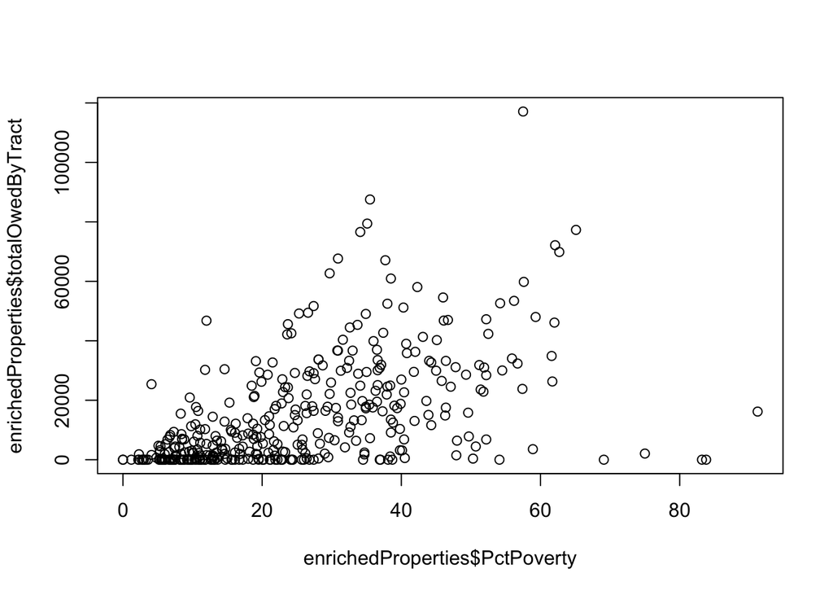

```r
plot(enrichedProperties$PctPoverty, enrichedProperties$totalOwedByTract)
```

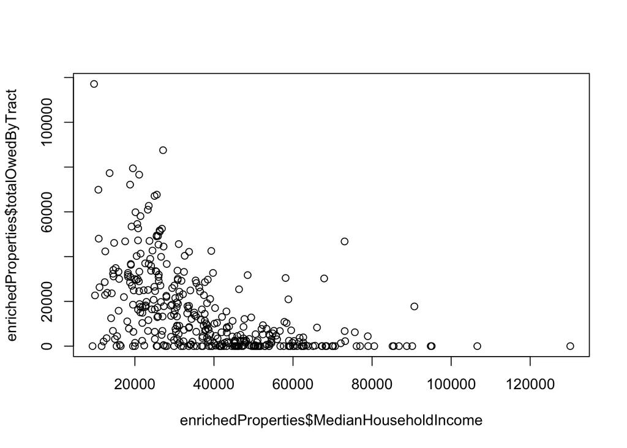

```r
plot(enrichedProperties$MedianHouseholdIncome, enrichedProperties$totalOwedByTract)
```

Certainly seems that way. Maybe deadbeat investors aren’t able to turn enough profit in poor areas to make their tax payments. Or maybe investors that don’t care to pay taxes flock to poorer areas. It’s not clear if there’s a causal link, and if so, in what direction. But there seems to be clear correlation:

```r
cor.test(enrichedProperties$PctPoverty, enrichedProperties$totalOwedByTract)
```

```
##
##  Pearson's product-moment correlation
##
## data:  enrichedProperties$PctPoverty and enrichedProperties$totalOwedByTract
## t = 11.788, df = 375, p-value < 2.2e-16
## alternative hypothesis: true correlation is not equal to 0
## 95 percent confidence interval:
##  0.4421764 0.5899749
## sample estimates:
##       cor
## 0.5199566
```

```r
cor.test(enrichedProperties$MedianHouseholdIncome, enrichedProperties$totalOwedByTract)
```

```
##
##  Pearson's product-moment correlation
##
## data:  enrichedProperties$MedianHouseholdIncome and enrichedProperties$totalOwedByTract
## t = -11.268, df = 373, p-value < 2.2e-16
## alternative hypothesis: true correlation is not equal to 0
## 95 percent confidence interval:
##  -0.5758204 -0.4243196
## sample estimates:
##        cor
## -0.5039359
```

Yep, there’s something interesting here. And more visualizations that make sense to do!